# 不完全なカウントデータから動物の個体数を推定する

Kanazawa.R #2

伊東宏樹

2024-11-23

## 動物の個体数推定

- 対象の動物が何匹（頭・羽）いるのか ← 基本情報
- カウント調査
- しかし、動物はいても、必ず発見できるとは限らない
- 不完全なカウントデータ

## N-mixtureモデル

反復調査（*j*回）により、実際の個体数(*N*<sub>i,</sub> *i*はサイト)と、発見確率(*p*)を推定

$$N_i \sim \mathrm{Poisson}(\lambda)$$

$$Y_{ij} \sim \mathrm{Binomial}(N_i, p)$$

- *N<sub>i</sub>*は、反復調査のあいだ変わらないことを仮定
- いないものを「発見」することや、ダブルカウントはないと仮定

## North American Breeding Bird Survey (BBS)

- 北米繁殖鳥調査
- 1960年代から続く大規模調査
- 北米一帯で4000以上の調査ルート
- 各調査ルートに50箇所サイト

## モリツグミ

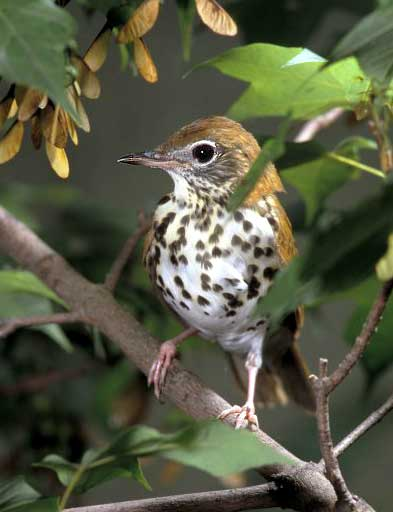

## 1991年6月のBBSモリツグミデータ

- unmarkedパッケージのbirdsデータに含まれる`woodthrush`データフレーム
- 50サイトで11回の反復調査

```
   1 2 3 4 5 6 7 8 9 10 11
1  1 1 0 1 2 2 2 3 1  2  2
2  1 2 2 1 1 2 1 1 1  2  2
3  0 1 1 1 0 0 1 1 0  1  1
4  4 2 2 2 1 2 2 2 2  3  2
5  2 1 1 1 0 1 1 2 1  2  2
6  3 1 2 2 1 1 1 1 1  2  0
7  0 1 1 1 1 1 1 0 0  1  1
8  1 1 0 2 0 0 1 1 1  1  1
9  1 1 1 2 2 0 0 0 0  0  1
10 1 1 0 0 2 1 1 1 1  1  0
11 0 0 0 1 0 0 0 1 1  0  0
12 0 0 0 0 0 1 1 1 0  0  0
13 1 1 1 0 1 0 1 0 1  2  1
14 2 0 0 0 0 1 1 1 1  1  1
```

[output cut: 36 more lines]

## グラフにすると

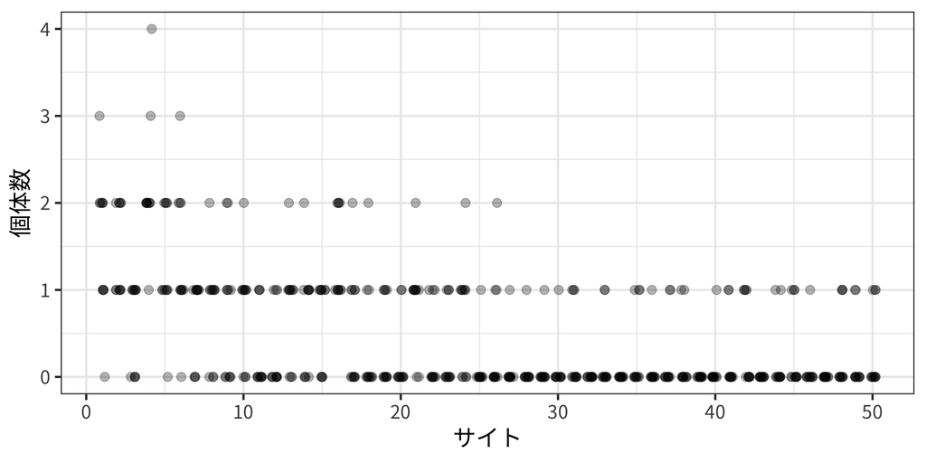

## Nimbleによるモデリング

- マルコフ連鎖モンテカルロ (MCMC) 法によるベイズ推定
- BUGS言語でモデルを記述

```r
code <- nimbleCode({
  for (i in 1:N_site) {
    N[i] ~ dpois(exp(log_lambda))
    for (j in 1:N_obs) {
      Y[i, j] ~ dbinom(ilogit(logit_p), N[i])
    }
  }
  log_lambda ~ dnorm(0, 1e-2)
  logit_p ~ dnorm(0, 1e-2)
})
```

## 結果

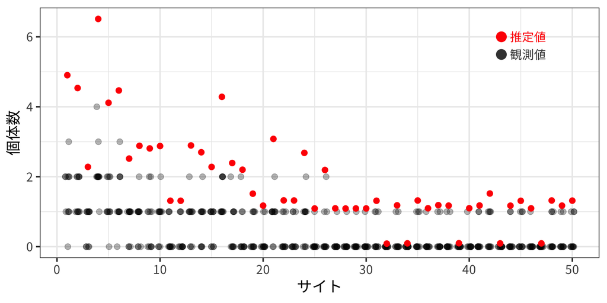

## 参考文献

- [『生態学のための階層モデリング―RとBUGSによる分布・個体数量・種の豊かさの統計解析―』](https://www.kyoritsu-pub.co.jp/book/b10003301.html), Marc Kéry, J. Andrew Royle 著, 深谷肇一・飯島勇人・伊東宏樹 監訳, 共立出版, 2021年